# Food Price Forecasting

Sanjeev N S

2023-12-11

**Importing datasets**

```r
dataset <- read.csv("C:\\Users\\sanjeev\\Desktop\\7TH SEM\\FDA\\india.csv")
```

```r
val <- read.csv("C:\\Users\\sanjeev\\Desktop\\7TH SEM\\FDA\\india_2019.csv")
```

```r
library(dplyr)
library(vars)
library(forecast)
```

```r
library(ggplot2)
library(prophet)
library(corrplot)
```

**basic analysis of dataset**

```r
head(dataset,7)
```

```
##      date Chickpeas Oil..mustard. Potatoes     Rice    Sugar    Wheat   Onions
## 1 2000-02  18.89667      45.69000 4.933333 236.4944 16.27059 205.0038 5.246667
## 2 2000-03  18.16000      43.62188 4.365000 223.2158 16.61389 245.0250 5.680000
## 3 2000-04  18.50000      42.96563 4.742500 231.9906 17.04167 234.0414 5.487500
## 4 2000-05  18.29500      41.34063 4.855000 231.3556 16.64167 219.6067 5.257500
## 5 2000-06  18.84000      42.08000 5.090000 230.8889 16.63529 217.8067 4.827500
## 6 2000-07  20.19000      41.89000 5.375000 208.4165 16.58529 214.5920 5.465000
## 7 2000-08  20.87500      42.21000 5.432500 206.1125 17.10278 208.8033 5.005000
```

```r
tail(dataset,5)
```

```
##        date Chickpeas Oil..mustard. Potatoes      Rice     Sugar     Wheat
## 223 2018-08   68.5550      107.5745 22.23929  233.3982  153.0002  205.7535
## 224 2018-09   68.0500      107.6900 22.11625  228.2709  151.4428  209.4359
## 225 2018-10   67.2250      107.3870 22.44964  227.0411  154.6581  214.8036
## 226 2018-11   69.0550      107.6817 21.88407  231.5347  155.3071  220.0250
## 227 2018-12   71.6775            NA 22.24500 1425.2675 1100.3533 1267.8212
##     Onions
## 223     NA
## 224     NA
## 225     NA
## 226     NA
## 227     NA
```

```r
head(val,6)
```

```
##      date Chickpeas Oil..mustard. Potatoes      Rice     Sugar     Wheat
## 1 2019-01   71.6900      107.8224 17.67143  229.4907  149.2781  205.4263
## 2 2019-02   70.6875            NA 18.19750 1479.5750 1123.2433 1296.9750
## 3 2019-03   68.0525            NA 17.09500 1467.2350 1123.9017 1267.3737
## 4 2019-04   67.6475            NA 19.14750 1416.3637 1130.6183 1185.3825
## 5 2019-05   69.8850            NA 20.84250 1415.8800 1161.2333 1167.4137
## 6 2019-06   72.2675      107.8661 16.26093  241.3713 1161.5917  198.4078
```

```r
tail(val,6)
```

```
##       date Chickpeas Oil..mustard. Potatoes     Rice    Sugar    Wheat
## 7  2019-07   69.9975      108.0691 19.00130 246.5215 156.9577 204.5098
## 8  2019-08   67.8225      107.6808 18.84926 241.9718 162.1139 208.2261
## 9  2019-09   68.3725      108.0647 19.03074 243.0373 164.7150 207.8159
## 10 2019-10   69.3050      108.4123 20.05167 240.8009 164.7157 215.3645
## 11 2019-11   70.9625      108.9847 22.08037 265.5830 162.8098 216.3760
## 12 2019-12   69.9175      110.2902 24.77278 272.7802 161.2989 218.8043
```

```r
summary(dataset)
```

```
##      date             Chickpeas      Oil..mustard.       Potatoes
##  Length:227         Min.   : 18.16   Min.   : 36.10   Min.   : 4.105
##  Class :character   1st Qu.: 24.88   1st Qu.: 56.80   1st Qu.: 8.123
##  Mode  :character   Median : 35.15   Median : 69.83   Median :11.053
##                     Mean   : 43.88   Mean   : 76.36   Mean   :12.316
##                     3rd Qu.: 54.92   3rd Qu.: 99.62   3rd Qu.:15.705
##                     Max.   :136.95   Max.   :113.38   Max.   :29.549
##                                      NA's   :11
##       Rice            Sugar             Wheat            Onions
##  Min.   : 166.4   Min.   :  14.52   Min.   : 149.8   Min.   : 4.803
##  1st Qu.: 199.0   1st Qu.:  16.86   1st Qu.: 187.0   1st Qu.: 7.641
##  Median : 221.0   Median : 128.04   Median : 206.7   Median :12.089
##  Mean   : 245.8   Mean   : 118.16   Mean   : 240.0   Mean   :15.247
##  3rd Qu.: 238.9   3rd Qu.: 168.95   3rd Qu.: 291.9   3rd Qu.:18.582
##  Max.   :1425.3   Max.   :1100.35   Max.   :1267.8   Max.   :57.066
##                                                      NA's   :11
```

```r
str(dataset)
```

```
## 'data.frame':    227 obs. of  8 variables:
##  $ date         : chr  "2000-02" "2000-03" "2000-04" "2000-05" ...
##  $ Chickpeas    : num  18.9 18.2 18.5 18.3 18.8 ...
##  $ Oil..mustard.: num  45.7 43.6 43 41.3 42.1 ...
##  $ Potatoes     : num  4.93 4.37 4.74 4.86 5.09 ...
##  $ Rice         : num  236 223 232 231 231 ...
##  $ Sugar        : num  16.3 16.6 17 16.6 16.6 ...
##  $ Wheat        : num  205 245 234 220 218 ...
##  $ Onions       : num  5.25 5.68 5.49 5.26 4.83 ...
```

```r
summary(val)
```

```
##      date             Chickpeas     Oil..mustard.      Potatoes
##  Length:12          Min.   :67.65   Min.   :107.7   Min.   :16.26
##  Class :character   1st Qu.:68.29   1st Qu.:107.9   1st Qu.:18.07
##  Mode  :character   Median :69.90   Median :108.1   Median :19.02
##                     Mean   :69.72   Mean   :108.4   Mean   :19.42
##                     3rd Qu.:70.76   3rd Qu.:108.6   3rd Qu.:20.25
##                     Max.   :72.27   Max.   :110.3   Max.   :24.77
##                                     NA's   :4
##       Rice            Sugar            Wheat
##  Min.   : 229.5   Min.   : 149.3   Min.   : 198.4
##  1st Qu.: 241.8   1st Qu.: 161.9   1st Qu.: 207.2
##  Median : 256.1   Median : 164.7   Median : 215.9
##  Mean   : 646.7   Mean   : 568.5   Mean   : 549.3
##  3rd Qu.:1416.0   3rd Qu.:1125.6   3rd Qu.:1171.9
##  Max.   :1479.6   Max.   :1161.6   Max.   :1297.0
##
```

```r
str(val)
```

```
## 'data.frame':    12 obs. of  7 variables:
##  $ date         : chr  "2019-01" "2019-02" "2019-03" "2019-04" ...
##  $ Chickpeas    : num  71.7 70.7 68.1 67.6 69.9 ...
##  $ Oil..mustard.: num  108 NA NA NA NA ...
##  $ Potatoes     : num  17.7 18.2 17.1 19.1 20.8 ...
##  $ Rice         : num  229 1480 1467 1416 1416 ...
##  $ Sugar        : num  149 1123 1124 1131 1161 ...
##  $ Wheat        : num  205 1297 1267 1185 1167 ...
```

**Missing Value analysis**

```r
colSums(is.na(dataset))
```

```
##          date     Chickpeas Oil..mustard.      Potatoes          Rice
##             0             0            11             0             0
##         Sugar         Wheat        Onions
##             0             0            11
```

```r
colSums(is.na(val))
```

```
##          date     Chickpeas Oil..mustard.      Potatoes          Rice
##             0             0             4             0             0
##         Sugar         Wheat
##             0             0
```

**missing value imputaion with mean**

```r
dataset <- dataset %>%
  mutate_if(is.numeric, ~ifelse(is.na(.), mean(., na.rm = TRUE), .))

colSums(is.na(dataset))
```

```
##          date     Chickpeas Oil..mustard.      Potatoes          Rice
##             0             0             0             0             0
##         Sugar         Wheat        Onions
##             0             0             0
```

```r
val <- val %>%
  mutate_if(is.numeric, ~ifelse(is.na(.), mean(., na.rm = TRUE), .))

colSums(is.na(val))
```

```
##          date     Chickpeas Oil..mustard.      Potatoes          Rice
##             0             0             0             0             0
##         Sugar         Wheat
##             0             0
```

**visualizations**

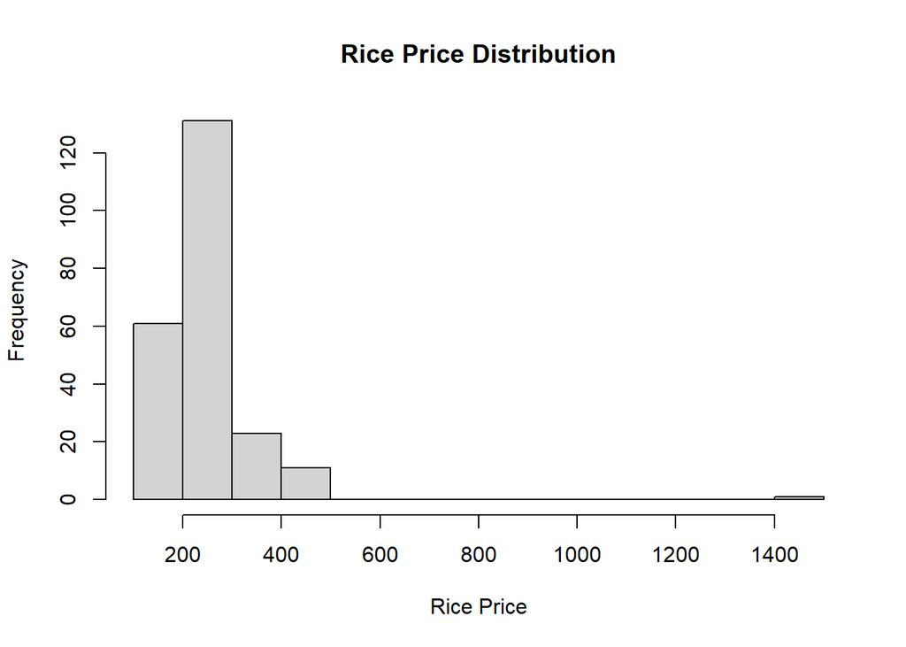

```r
hist(dataset$Rice, main = "Rice Price Distribution", xlab = "Rice Price")
```

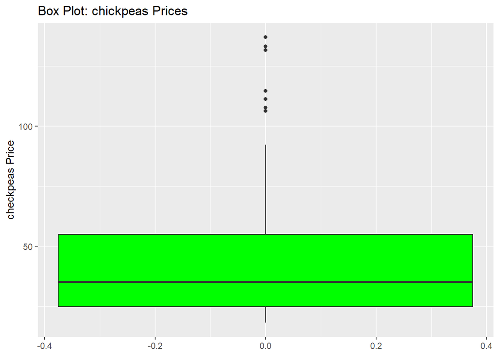

```r
ggplot(dataset, aes(y =Chickpeas )) +
  geom_boxplot(fill = "green") +
  labs(title = "Box Plot: chickpeas Prices", y = "checkpeas Price")
```

[figure not shown]

```r
ggplot(dataset, aes(y =Chickpeas )) +
  geom_boxplot(fill = "red") +
  labs(title = "Box Plot: Oil..mustard. Prices", y = "Oil..mustard. Price")
```

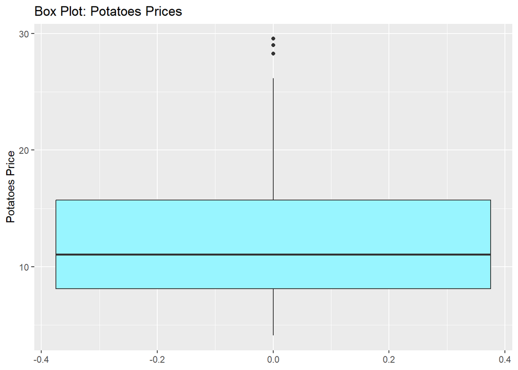

```r
ggplot(dataset, aes(y =Potatoes )) +
  geom_boxplot(fill = "cadetblue1") +
  labs(title = "Box Plot: Potatoes Prices", y = "Potatoes Price")
```

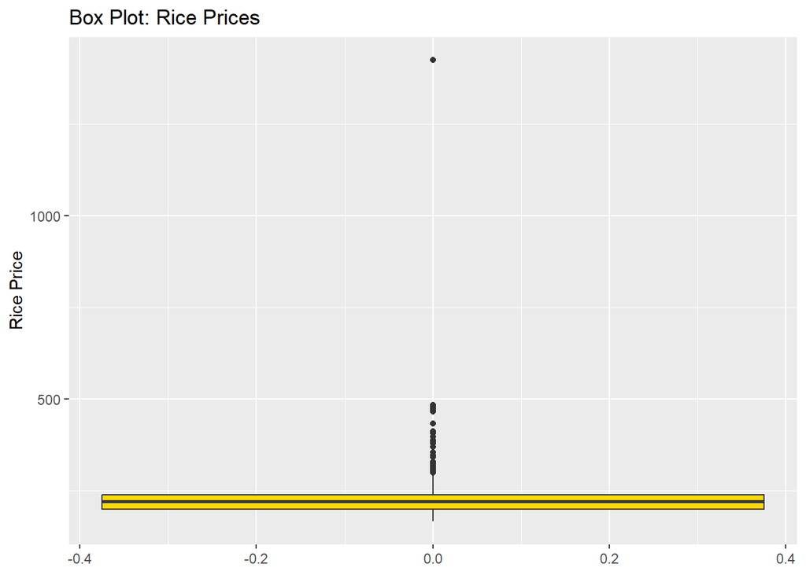

```r
ggplot(dataset, aes(y =Rice )) +
  geom_boxplot(fill = "gold1") +
  labs(title = "Box Plot: Rice Prices", y = "Rice Price")
```

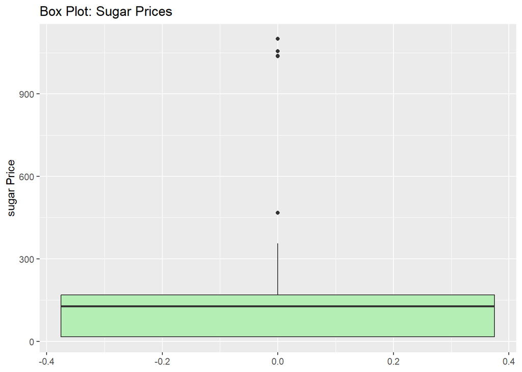

```r
ggplot(dataset, aes(y =Sugar )) +
  geom_boxplot(fill = "darkseagreen2") +
  labs(title = "Box Plot: Sugar Prices", y = "sugar Price")
```

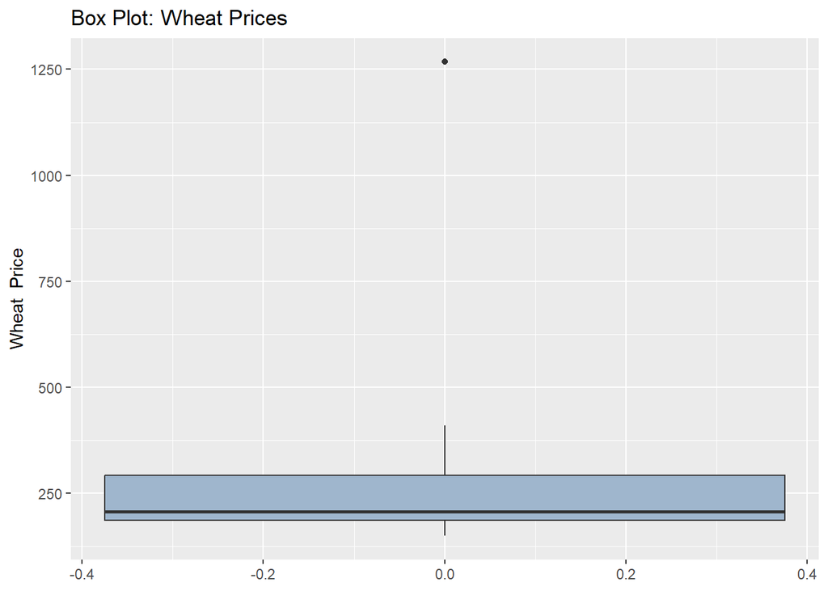

```r
ggplot(dataset, aes(y =Wheat )) +
  geom_boxplot(fill = "slategray3") +
  labs(title = "Box Plot: Wheat Prices", y = "Wheat  Price")
```

*outlier detection Function to identify outliers

```r
identify_outliers <- function(data, columns, threshold = 1.5) {
  for (col in columns) {
    q1 <- quantile(data[[col]], 0.25)
    q3 <- quantile(data[[col]], 0.75)
    iqr <- q3 - q1
    lower_bound <- q1 - threshold * iqr
    upper_bound <- q3 + threshold * iqr

    # Identify outliers
    outliers <- data[[col]] < lower_bound | data[[col]] > upper_bound
    print(outliers)
  }
}

identify_outliers(dataset, c("Chickpeas", "Oil..mustard.", "Potatoes", "Rice", "Sugar", "Wheat", "Onions"))
```

[output not shown]

[output cut: 118 more lines]

```r
identify_outliers(val, c("Chickpeas", "Oil..mustard.", "Potatoes", "Rice", "Sugar", "Wheat", "Onions"))
```

```
##  [1] FALSE FALSE FALSE FALSE FALSE FALSE FALSE FALSE FALSE FALSE FALSE FALSE
##  [1] FALSE FALSE FALSE FALSE FALSE FALSE FALSE FALSE FALSE FALSE  TRUE  TRUE
##  [1] FALSE FALSE FALSE FALSE FALSE FALSE FALSE FALSE FALSE FALSE FALSE  TRUE
##  [1] FALSE FALSE FALSE FALSE FALSE FALSE FALSE FALSE FALSE FALSE FALSE FALSE
##  [1] FALSE FALSE FALSE FALSE FALSE FALSE FALSE FALSE FALSE FALSE FALSE FALSE
##  [1] FALSE FALSE FALSE FALSE FALSE FALSE FALSE FALSE FALSE FALSE FALSE FALSE
## logical(0)
```

Function to identify and replace outliers with mean

```r
identify_and_replace_outliers_with_mean <- function(data, columns, threshold = 1.5) {
  for (col in columns) {
    q1 <- quantile(data[[col]], 0.25)
    q3 <- quantile(data[[col]], 0.75)
    iqr <- q3 - q1
    lower_bound <- q1 - threshold * iqr
    upper_bound <- q3 + threshold * iqr


    outliers <- data[[col]] < lower_bound | data[[col]] > upper_bound


    data[[col]][outliers] <- mean(data[[col]], na.rm = TRUE)
  }
  return(data)
}

dataset <- identify_and_replace_outliers_with_mean(dataset, c("Chickpeas", "Oil..mustard.", "Potatoes", "Rice", "Sugar", "Wheat", "Onions"))



identify_outliers <- function(data, columns, threshold = 1.5) {
  for (col in columns) {
    q1 <- quantile(data[[col]], 0.25)
    q3 <- quantile(data[[col]], 0.75)
    iqr <- q3 - q1
    lower_bound <- q1 - threshold * iqr
    upper_bound <- q3 + threshold * iqr

    # Identify outliers
    outliers <- data[[col]] < lower_bound | data[[col]] > upper_bound
    print(outliers)
  }

}

identify_outliers(dataset, c("Chickpeas", "Oil..mustard.", "Potatoes", "Rice", "Sugar", "Wheat", "Onions"))
```

[output not shown]

[output cut: 118 more lines]

```r
val <- identify_and_replace_outliers_with_mean(val, c("Chickpeas", "Oil..mustard.", "Potatoes", "Rice", "Sugar", "Wheat"))
```

```r
identify_outliers(val, c("Chickpeas", "Oil..mustard.", "Potatoes", "Rice", "Sugar", "Wheat"))
```

```
##  [1] FALSE FALSE FALSE FALSE FALSE FALSE FALSE FALSE FALSE FALSE FALSE FALSE
##  [1] FALSE FALSE FALSE FALSE FALSE FALSE FALSE FALSE FALSE FALSE FALSE FALSE
##  [1] FALSE FALSE FALSE FALSE FALSE FALSE FALSE FALSE FALSE FALSE  TRUE FALSE
##  [1] FALSE FALSE FALSE FALSE FALSE FALSE FALSE FALSE FALSE FALSE FALSE FALSE
##  [1] FALSE FALSE FALSE FALSE FALSE FALSE FALSE FALSE FALSE FALSE FALSE FALSE
##  [1] FALSE FALSE FALSE FALSE FALSE FALSE FALSE FALSE FALSE FALSE FALSE FALSE
```

**data type conversion** converting date atribute from “string” datatype to “date” datatype

```r
dataset$date <- as.Date(dataset$date,format="%Y-%m")
class(dataset$date)
```

```
## [1] "Date"
```

```r
val$date <- as.Date(val$date,format="%Y-%m")
class(val$date)
```

```
## [1] "Date"
```

**FORECASTING MODELS**

```r
cat("\n")
```

**ARIMA MODEL**

```r
# Create a time series object
rice_ts <- ts(dataset$Rice, frequency = 12, start = c(2000, 2))
arima_model <- auto.arima(rice_ts)
forecast_values <- forecast(arima_model, h = 12)
print(forecast_values)
```

```
##          Point Forecast    Lo 80    Hi 80    Lo 95    Hi 95
## Jan 2019       240.2410 225.8727 254.6094 218.2665 262.2155
## Feb 2019       239.8918 222.4352 257.3485 213.1942 266.5894
## Mar 2019       238.2950 218.2883 258.3017 207.6974 268.8926
## Apr 2019       237.7963 215.9525 259.6400 204.3892 271.2034
## May 2019       235.6846 212.4063 258.9629 200.0835 271.2857
## Jun 2019       235.0911 210.6825 259.4997 197.7614 272.4208
## Jul 2019       233.9757 208.6620 259.2893 195.2618 272.6895
## Aug 2019       233.1934 207.1487 259.2381 193.3615 273.0254
## Sep 2019       231.8769 205.2374 258.5164 191.1354 272.6184
## Oct 2019       230.7156 203.5898 257.8414 189.2303 272.2009
## Nov 2019       230.4483 202.9233 257.9734 188.3524 272.5442
## Dec 2019       231.3627 203.5089 259.2165 188.7640 273.9614
```

```r
point_forecasts <- forecast_values$mean
error_arima <- sum(point_forecasts-val$Rice)/12
error_arima
```

```
## [1] -411.8365
```

**Exponential Smoothing (ETS)**

```r
ets_model <- ets(rice_ts)
forecast_values_ets <- forecast(ets_model, h = 12)
print(forecast_values_ets)
```

```
##          Point Forecast    Lo 80    Hi 80    Lo 95    Hi 95
## Jan 2019       242.0348 226.8731 257.1964 218.8470 265.2225
## Feb 2019       242.0348 223.0577 261.0118 213.0119 271.0576
## Mar 2019       242.0348 219.8863 264.1832 208.1616 275.9079
## Apr 2019       242.0348 217.1117 266.9578 203.9182 280.1513
## May 2019       242.0348 214.6133 269.4562 200.0972 283.9723
## Jun 2019       242.0348 212.3212 271.7483 196.5918 287.4777
## Jul 2019       242.0348 210.1909 273.8786 193.3339 290.7357
## Aug 2019       242.0348 208.1919 275.8776 190.2766 293.7929
## Sep 2019       242.0348 206.3020 277.7675 187.3863 296.6832
## Oct 2019       242.0348 204.5049 279.5646 184.6378 299.4318
## Nov 2019       242.0348 202.7877 281.2819 182.0115 302.0580
## Dec 2019       242.0348 201.1403 282.9292 179.4921 304.5774
```

```r
point_forecasts <- forecast_values_ets$mean
error_ETS <- sum(point_forecasts-val$Rice)/12
error_ETS
```

```
## [1] -404.6828
```

**SARIMA (Seasonal ARIMA)**

```r
sarima_model <- arima(dataset$Rice, order = c(1, 1, 1), seasonal = list(order = c(1, 1, 1)), method = "CSS")
forecast_values_sarima <- forecast(sarima_model, h = 12)
print(forecast_values_sarima)
```

```
##     Point Forecast    Lo 80    Hi 80    Lo 95    Hi 95
## 228       242.8970 227.4906 258.3035 219.3349 266.4592
## 229       242.6623 222.8460 262.4787 212.3558 272.9689
## 230       243.6357 220.3618 266.9096 208.0413 279.2301
## 231       244.9132 218.1651 271.6613 204.0056 285.8208
## 232       246.2551 215.8433 276.6668 199.7443 292.7659
## 233       247.6095 213.3264 281.8927 195.1780 300.0411
## 234       248.9663 210.6133 287.3192 190.3104 307.6221
## 235       250.3234 207.7141 292.9327 185.1581 315.4887
## 236       251.6806 204.6390 298.7222 179.7367 323.6245
## 237       253.0379 201.3969 304.6788 174.0598 332.0159
## 238       254.3951 197.9953 310.7949 168.1391 340.6511
## 239       255.7523 194.4407 317.0640 161.9843 349.5204
```

```r
point_forecasts <- forecast_values_sarima$mean
error_SARIMA <- sum(point_forecasts-val$Rice)/12
error_SARIMA
```

```
## [1] -398.2068
```

**VECTOR AUTOREGRESSION MODEL[VAR]**

```r
multivariate_data <- dataset[, c("Rice", "Wheat")]

# Convert the data to time series format
ts_data <- ts(multivariate_data, frequency = 12, start = c(2000, 2))

# Fit VAR model
var_model <- VAR(ts_data, p = 2)  # Specify the lag order (p) based on your data


forecast_horizon <- 12
forecast_values <- predict(var_model, n.ahead = forecast_horizon)[]
```

```r
# Print the point forecast values
print(forecast_values$fcst$Rice[,1])
```

```
##  [1] 239.6247 238.5616 236.4626 234.9585 233.5704 232.3838 231.3408 230.4273
##  [9] 229.6225 228.9111 228.2797 227.7173
```

```r
error_VAR <- sum(forecast_values$fcst$Rice[,1]-val$Rice)/12
error_VAR
```

```
## [1] -414.0625
```

**validation** comparision of forecasting models

```r
cat("ARIMA ERROR: ", error_arima, "\n")
```

```
## ARIMA ERROR:  -411.8365
```

```r
cat("Exponential Smoothing ERROR: ", error_ETS, "\n")
```

```
## Exponential Smoothing ERROR:  -404.6828
```

```r
cat("SARIMA ERROR: ", error_SARIMA, "\n")
```

```
## SARIMA ERROR:  -398.2068
```

```r
cat("Vector Autoregression (VAR): ", error_VAR, "\n")
```

```
## Vector Autoregression (VAR):  -414.0625
```

```r
best_model <- ifelse(error_arima >= error_SARIMA & error_arima >= error_ETS & error_arima >= error_VAR, "ARIMA",
                   ifelse(error_ETS >= error_arima & error_ETS >= error_SARIMA & error_ETS >= error_VAR, "Exponential Smoothing",
                   ifelse(error_VAR >= error_SARIMA & error_VAR >= error_ETS, "Vector Autoregression (VAR)", "SARIMA(Seasonal ARIMA)")))

print(best_model)
```

```
## [1] "SARIMA(Seasonal ARIMA)"
```

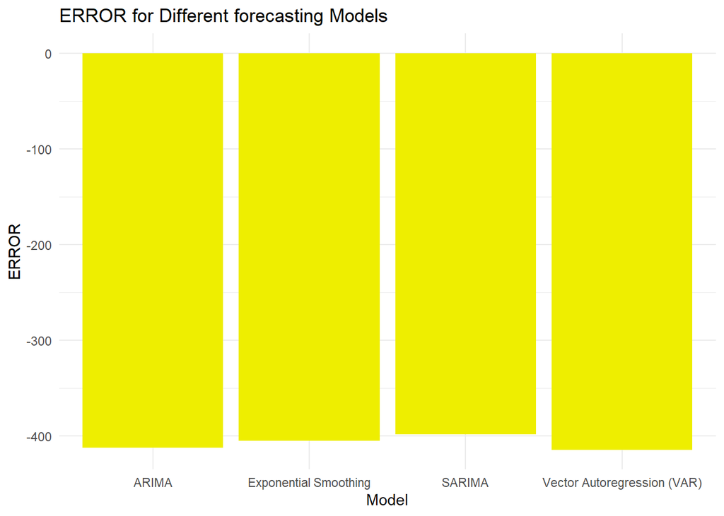

```r
models <- c("ARIMA", "Exponential Smoothing", "SARIMA","Vector Autoregression (VAR)")
error_values <- c(error_arima,error_ETS,error_SARIMA,error_VAR)

# Create a data frame
error_data <- data.frame(Model = models, ERROR = error_values)

ggplot(error_data, aes(x = Model, y = ERROR)) +
  geom_bar(stat = "identity", fill = "yellow2") +
  labs(title = "ERROR for Different forecasting Models",
       x = "Model",
       y = "ERROR") +
  theme_minimal()
```

we can observe visually that SARIMA model has less error than other models,so SARIMA model is a best model to forecast the prices

**PRIDICTIVE MODEL** **REGRESSION MODEL**

```r
# Select relevant predictors (features) and the target variable (rice price)
rice_data <- dplyr::select(as.data.frame(dataset), date, Sugar, Potatoes, Wheat, Rice)

# Split the data into training and testing sets
set.seed(123)  # for reproducibility
sample_size <- 0.8  # 80% training, 20% testing

# Create a training set
train_indices <- sample(1:nrow(rice_data), sample_size * nrow(rice_data))
train_data <- rice_data[train_indices, ]
test_data <- rice_data[-train_indices, ]
```

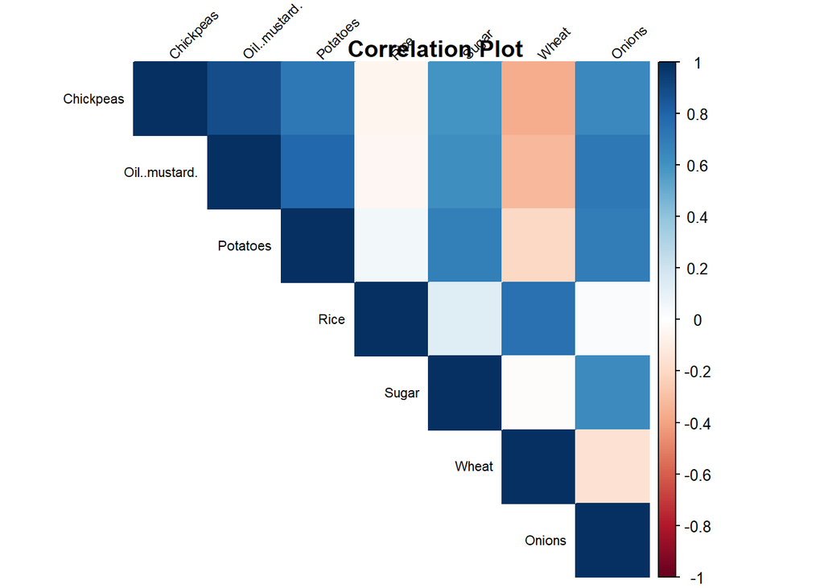

```r
numeric_data <- dplyr::select(dataset, -date)
correlation_matrix <- cor(numeric_data)
corrplot(correlation_matrix, method = "color", type = "upper",
         tl.cex = 0.7, tl.col = "black", tl.srt = 45)
title("Correlation Plot")
```

from the correlation matrix, for predicting rice , we can use potatoes, sugar and Wheat as independent variable as they are positively correlated

```r
# Fit a linear regression model
rice_lm_model <- lm(Rice ~  Potatoes + Wheat + Sugar, data = train_data)
```

```r
# Predict rice prices for the test set
rice_lm_predictions <- predict(rice_lm_model, newdata = test_data)
rice_lm_predictions
```

```
##        2        3       12       15       18       19       28       29
## 214.8946 212.2697 206.0865 206.2644 258.3690 254.9886 206.6505 207.2467
##       31       37       47       61       65       73       80       82
## 209.2712 207.3628 207.2509 207.1967 209.0817 224.1983 234.6192 245.5794
##       84       96      101      105      108      119      120      130
## 244.5178 240.5496 242.4522 243.2512 247.7194 271.2169 268.7998 262.8007
##      131      132      134      138      142      154      156      157
## 262.2491 210.7975 206.7318 203.2213 199.0307 214.3209 214.2164 215.3640
##      158      162      168      172      174      177      183      193
## 216.2255 221.2652 219.1250 220.4402 224.6878 211.6846 203.4192 208.0906
##      198      199      201      204      210      225
## 217.9490 219.1358 218.2405 216.3261 209.8298 226.8657
```

```r
# Calculate RMSE
rmse_reg_model <- sqrt(mean((test_data$Rice - rice_lm_predictions)^2))

cat("REGRESSION RMSE: ", rmse_reg_model, "\n")
```

```
## REGRESSION RMSE:  16.97897
```

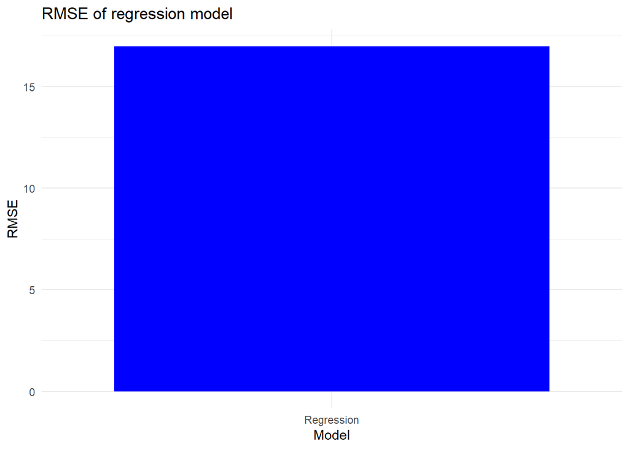

```r
# Define the RMSE values for  model
models <-  "Regression"
rmse_values <- rmse_reg_model

# Create a data frame
rmse_data <- data.frame(Model = models, RMSE = rmse_values)

# Create a bar plot
library(ggplot2)

ggplot(rmse_data, aes(x = Model, y = RMSE)) +
  geom_bar(stat = "identity", fill = "blue") +
  labs(title = "RMSE of regression model",
       x = "Model",
       y = "RMSE") +
  theme_minimal()
```

WE HAVE BUILT REGGRESSION MODEL FOR PREDICTIVE MODLES.THIS MODEL PREDICTS THE FOOD PRICE BASED ON THE OTHER ATRIBUTES PRICES.IN THIS CASE,RICE PRICE IS PREDICTED WITH THE PRICES OF POTATOES,WHEAT AND SUGAR.THESE ATRIBUTES ARE SELECTED BASED ON THE CORRELATION MATRIX OF THE DATASET